# Reproduction and alternative analysis of “Comparing the Biological Impact of Glatiramer Acetate with the Biological Impact of a Generic”

2014-03-01 17:14:48

### Overview

This report aims to show that the use of the statistical tool ComBat from [Johnson et al.](http://biostatistics.oxfordjournals.org/content/8/1/118.abstract) led to false results in the analysis performed in [Towfic et al.'s](http://www.plosone.org/article/info%3Adoi%2F10.1371%2Fjournal.pone.0083757) “Comparing the Biological Impact of Glatiramer Acetate with the Biological Impact of a Generic”.

This document has five main parts

- Getting and formatting the data
- Reproduce some of the results to show that we are working on the same data and analysis workflow
- Remove the use of ComBat and perform an similar analysis with alternative established tools
- Estimate the error introduced by ComBat and the consequences for the conclusion of the study
- Perform a few more sanity checks to substantiate that the difference in results for the two above analysis is mainly introduced by ComBat

### Getting the data

```r
includelibs = c("Biobase", "GEOquery", "sva", "limma", "preprocessCore")
lapply(includelibs, require, character.only = T)
```

The important sample information is described in Table S1 from Towfic et al. and its usage in ComBat is described briefly in the methods;

> Each microarrays chip designation was supplied a batch label; there were 18 batches in all. The labels for the treatments (i.e. drug product, reference standard ) were added as covariates. Towfic et al.

Table S1 does have a “Chip”- coloumn, unfortunatly there is no dedicated “treatment”-coloumn. Communication with the corresponding author yielded this explanation

> ..and the only thing we used as a covariate was the unique treatment names themselves (e.g. ³Medium² or ³RS").

Based on these descriptions and the annotation for the GEO deposit, we compiled a more complete sample annotation file (sampleannotation.csv).

```r
sampleannotation = read.table("data/sampleannotation.csv", sep = "\t", header = TRUE,
    stringsAsFactors = FALSE)
sampleannotation$code = make.names(sampleannotation$code)
sampleannotation$chip = as.character(sampleannotation$chip)
dimnames(sampleannotation)[[1]] = sampleannotation$code
head(sampleannotation)
```

```
##       number  code covariate       chip slot geogroup geoaccession
## RS.16      1 RS.16        RS 4634633002    A Verified    GSM996691
## DP.34      2 DP.34        DP 4634633002    B Verified    GSM996731
## DP.19      3 DP.19        DP 4634633002    C Verified    GSM996716
## DP.32      4 DP.32        DP 4634633002    D Verified    GSM996729
## DP.04      5 DP.04        DP 4634633002    E Verified    GSM996701
## MBP        6   MBP       MBP 4634633002    F    other    GSM996658
```

The “covariate”-coloumn is made based on the “code”-coloumn, but might not match to what were actually used for all samples. The last two coloumns are from the GEO deposit and reveal that 3 of the samples do not have data and are taken out.

The nameing convention seeme to differ slightly between the Table S1 and the text in Towfic et al. This is our interpretation of covariate labels and its corresponding name in the text.

- **DP** refferd to as GA (but not GA as in table S1)
- **N** refferd to as “generic”
- **M** reffered to as “medium”
- **RS** reffered to as “reference standard”“

```r
# take out 3 samples that are not assign to a geoaccession. Failed QC?
sampleannotation = sampleannotation[!is.na(sampleannotation$geoaccession), ]
```

The batch/covariate design shows many batches and covariate groups.

```r
table(sampleannotation[, c("chip", "covariate")])
```

```
##             covariate
## chip         A C DM DP E GA M MANITOL MBP N RS S TV
##   4634633002 0 0  0  4 0  0 0       0   1 0  1 0  0
##   4634633043 0 0  1  0 0  1 1       0   0 2  1 0  0
##   4634633053 0 0  1  1 0  0 0       0   0 1  1 0  0
##   4637105025 0 0  0  5 0  0 0       1   0 0  0 0  0
##   4682416019 0 0  0  4 0  0 0       0   0 0  2 0  0
##   4682416043 0 0  0  1 0  2 0       0   0 1  2 0  0
##   4682416087 0 0  1  0 0  0 1       0   0 0  1 0  3
##   4682416090 0 0  0  4 0  0 1       0   0 1  0 0  0
##   4763128059 0 0  1  2 0  0 1       0   0 1  1 0  0
##   4763128060 0 0  1  2 0  0 1       0   0 1  1 0  0
##   4763646004 0 0  0  1 0  0 1       0   0 0  4 0  0
##   4763646012 0 1  0  1 0  0 1       0   0 2  1 0  0
##   4763646026 0 1  0  1 0  0 1       0   0 2  1 0  0
##   4763646030 0 0  0  2 0  0 2       0   0 0  2 0  0
##   5216898004 1 0  0  2 0  0 1       0   0 0  1 0  0
##   5216898008 0 0  0  2 0  0 1       0   0 0  1 1  1
##   5216898012 2 0  0  1 1  0 1       0   0 0  1 0  0
##   5216898024 0 0  0  1 1  0 1       0   0 0  1 1  1
```

A look at the most interesting groups, "DP”(drug product) and “N”(generic) reveals a lack of balance.

```r
table(sampleannotation[sampleannotation$covariate %in% c("DP", "N"), c("chip",
    "covariate")])
```

```
##             covariate
## chip         DP N
##   4634633002  4 0
##   4634633043  0 2
##   4634633053  1 1
##   4637105025  5 0
##   4682416019  4 0
##   4682416043  1 1
##   4682416090  4 1
##   4763128059  2 1
##   4763128060  2 1
##   4763646004  1 0
##   4763646012  1 2
##   4763646026  1 2
##   4763646030  2 0
##   5216898004  2 0
##   5216898008  2 0
##   5216898012  1 0
##   5216898024  1 0
```

> The microarray data have been deposited in the Gene Expression Omnibus, under accession number GSE40566

The processed data from the above GEO deposit was from another publication which did not processes the data as described in Towfic et al. (personal communication). The lesser processed linked to as [GSE40566_non_normalized.txt.gz](http://www.ncbi.nlm.nih.gov/geo/download/?acc=GSE40566&format=file&file=GSE40566%5Fnon%5Fnormalized%2Etxt%2Egz) in the supplementary data was thus used in this report, although it is not confirmed that this is the version of the data actually used in Towfic et al.

Probe annotation was also found in the supplementary data as [GSE40566_RAW.tar](http://www.ncbi.nlm.nih.gov/geo/download/?acc=GSE40566&format=file).

A recap of the important input files used in this report:

- **sampleannotation.csv** holds the important sample/batch/covariate assignment. Compiled based on inforamtion in Towfic et al, the geo deposit and personal communication.
- **GSE40566_non_normalized.txt** the measurments in a sample vs probe matrix. From the [GEO deposit](http://www.ncbi.nlm.nih.gov/geo/download/?acc=GSE40566&format=file&file=GSE40566%5Fnon%5Fnormalized%2Etxt%2Egz).
- **GPL6887_MouseWG-6_V2_0_R3_11278593_A.txt** the probe annotation needed for the datarow to probe to gene matching. From the GEO deposit inside the [GSE40566_RAW.tar](http://www.ncbi.nlm.nih.gov/geo/download/?acc=GSE40566&format=file).

Reading the data.

```r
# the output from Illumina software.
rawdata = read.table("not_in_github/GSE40566_non_normalized.txt", sep = "\t",
    header = TRUE, stringsAsFactors = FALSE)

# the probe annotation file found inside GSE40566_RAW.tar
rawannotation = read.table("not_in_github/GPL6887_MouseWG-6_V2_0_R3_11278593_A.txt",
    sep = "\t", header = TRUE, stringsAsFactors = FALSE, skip = 8, comment.char = "",
    quote = "", fill = TRUE)
```

Some formatting is needed to match the probe information to the measurments and the measurments to the sample information.

```r
# annotation file has two separate tables, one for experimental and one at
# the end for controls.  splitting and fixing the tables:
tmp = rawannotation$Species == "Mus musculus"
experimentalannot = rawannotation[tmp, ]
experimentalannot$Array_Address_Id = as.numeric(experimentalannot$Array_Address_Id)
controlannot = rawannotation[!tmp, ]
dimnames(controlannot)[[2]] = rawannotation[rawannotation[, 2] == "Array_Address_Id",
    ]
controlannot$Array_Address_Id = suppressWarnings(as.numeric(controlannot$Array_Address_Id))
controlannot = controlannot[!is.na(controlannot$Array_Address_Id), ]
controlannot = controlannot[, 1:6]
probeannotation = merge(experimentalannot, controlannot, all = TRUE)
# dim(probeannotation)
rm(tmp, experimentalannot, controlannot)

probeannotation = probeannotation[!duplicated(probeannotation$Array_Address_Id),
    ]
probeannotation = probeannotation[probeannotation$Array_Address_Id %in% rawdata$ID_REF,
    ]  #
probeannotation$Symbol = tolower(probeannotation$Symbol)
dimnames(probeannotation)[[1]] = probeannotation$Probe_Id
# dim(probeannotation)

# sort and filter probe and data similar.
datamatrix_raw = as.matrix(rawdata[, -1])
datamatrix_raw = datamatrix_raw[match(probeannotation$Array_Address_Id, rawdata$ID_REF),
    ]
dimnames(datamatrix_raw)[[1]] = probeannotation$Probe_Id
# dim(datamatrix_raw) dim(probeannotation)

# and match data to samples. table(sampleannotation$code %in%
# dimnames(datamatrix_raw)[[2]])# check table(dimnames(datamatrix_raw)[[2]]
# %in% sampleannotation$code)# check
datamatrix_raw = datamatrix_raw[, match(sampleannotation$code, dimnames(datamatrix_raw)[[2]])]
```

Several tables with results are presented in the Supporting Information in Towfic et al. We are aiming to reproduce these. Unfortunatly these were only presented in a pdf-format not easely parsed by a computer. We had to resort to a ad-hoc method of cut-and-paste from pdf into text files which were somewhat polluted by pdf-formatting code. For some tables about 10% of the rows will be lost, but the rest will suffice for our purpose.

```r
# Table S2
table_s2 = read.table("data/table_s2.csv", sep = "\t", header = TRUE, stringsAsFactors = FALSE,
    fill = TRUE)
table_s2 = as.matrix(table_s2)
table_s2[, 3:6] = as.numeric(table_s2[, 3:6])
# not able to paste the pdf whitout a lot of gibberish clutter the data.
# Some probes are lost!
a = rowSums(is.na(table_s2[, 3:6])) > 0
print(paste("Lost rows table s2: ", sum(a)))
```

```
## [1] "Lost rows table s2:  91"
```

```r
table_s2 = data.frame(table_s2[!a, ], stringsAsFactors = FALSE)
# data.frame makes the columns characters again.
for (n in 3:6) {
    table_s2[, n] = as.numeric(table_s2[, n])
}

# Table S3
table_s3 = read.table("data/table_s3.csv", sep = "\t", header = TRUE, stringsAsFactors = FALSE,
    fill = TRUE)
# one Probe, ('1770446' or 'ILM_1770446') was not found in the data and was
# thus removed from this textfile

# Table S4
table_s4 = read.table("data/table_s4.csv", sep = "\t", header = TRUE, stringsAsFactors = FALSE,
    fill = TRUE)
# not able to copy-paste the pdf whitout a lot of gibberish clutter the
# data. Some probes are lost!
a = is.na(as.numeric(table_s4$Var_generic_vs_Var_GA))
print(paste("Lost rows table s4: ", sum(a)))
```

```
## [1] "Lost rows table s4:  1"
```

```r
table_s4 = table_s4[!a, ]
table_s4$Var_generic_vs_Var_GA = as.numeric(table_s4$Var_generic_vs_Var_GA)

# Table S5
table_s5 = read.table("data/table_s5.csv", sep = "\t", header = TRUE, stringsAsFactors = FALSE,
    fill = TRUE)
tmp = as.matrix(table_s5)
tmp[, 3:14] = as.numeric(tmp[, 3:14])
# not able to paste the pdf whitout a lot of gibberish clutter the data.
# Some probes are lost!
a = rowSums(is.na(tmp[, 3:14])) > 0
print(paste("Lost rows table s5: ", sum(a)))
```

```
## [1] "Lost rows table s5:  15"
```

```r
table_s5 = data.frame(table_s5[!a, ], stringsAsFactors = FALSE)
table_s5$Fold_Change = as.numeric(table_s5$Fold_Change)
```

### Reproduce the original results

Or at least some of it.

> Starting with background-corrected bead-level signals, we quantile normalized the extracted data for all samples across all 46,547 probes via the preprocessCore package in R.

```r
datamatrices = list()
datamatrices[["real_raw"]] = datamatrix_raw  #[1:5000,]

# used in paper, but seems to do the same as the limma version. Except it
# loses dimnames
datamatrices[["real_qnorm"]] = normalize.quantiles(datamatrices[["real_raw"]])
dimnames(datamatrices[["real_qnorm"]]) = dimnames(datamatrices[["real_raw"]])
```

> We then corrected for batch variation with ComBat [17] as implemented in the SVA package of R [18]. Each microarrays chip designation was supplied a batch label; there were 18 batches in all. The labels for the treatments (i.e. drug product, reference standard ) were added as covariates.

```r
mod = model.matrix(~as.factor(sampleannotation$covariate))
mod0 = model.matrix(~1, data = sampleannotation)

datamatrices[["real_combat_covariates"]] = as.matrix(ComBat(dat = datamatrices[["real_qnorm"]],
    batch = sampleannotation$chip, mod = mod, numCovs = NULL, par.prior = TRUE,
    prior.plots = FALSE))
```

```
## Found 18 batches
## Found 12  categorical covariate(s)
## Standardizing Data across genes
## Fitting L/S model and finding priors
## Finding parametric adjustments
## Adjusting the Data
```

First we will try to reproduce Table S2.

> Genes utilized for the tolerance method illustrated in Figure 1B. (figure text)

> This standard of comparison was constructed by first identifying the top 1000 probes by absolute fold change of reference standard compared to the medium (Table S2). The list includes both upregulated and downregulated probes compared to medium. Probes were filtered such that ones upregulated by reference standard needed to have an average reference standard expression of 6.00 or higher and ones downregulated by reference standard needed to have an average medium expression of 6.00 or higher.

This is how the table looks

```r
head(table_s2)
```

```
##             ID         Gene AVG_Medium AVG_Reference_Standard AVG_GA
## 1 ILMN_2685712         IFNG      7.152                 11.255 11.163
## 2 ILMN_1247309          IL3      5.823                  9.406  9.384
## 3 ILMN_2791459         IFNG      6.636                  9.829  9.711
## 4 ILMN_1215862        CXCL9      7.342                  9.817  9.757
## 5 ILMN_2595732 LOC100046232      9.249                 11.509 11.547
## 6 ILMN_2931334          IL4      6.172                  8.367  8.425
##   AVG_generic
## 1      10.668
## 2       9.422
## 3       9.304
## 4       9.525
## 5      11.767
## 6       8.496
```

**Table S2**

```r
thiscovariatename = "covariate"
thisdata = datamatrices[["real_combat_covariates"]]

# the mean uses log2 numbers and will be a geometric mean.
meanM = rowMeans(thisdata[, sampleannotation[, "covariate"] == "M"])
meanRS = rowMeans(thisdata[, sampleannotation[, "covariate"] == "RS"])
meanDP = rowMeans(thisdata[, sampleannotation[, "covariate"] == "DP"])
meanN = rowMeans(thisdata[, sampleannotation[, "covariate"] == "N"])

foldchange_RS_vs_M = meanRS - meanM
foldchange_RS_vs_M = foldchange_RS_vs_M[meanM > 6 | meanRS > 6]
top1000_RS_vs_M = names(foldchange_RS_vs_M[order(abs(foldchange_RS_vs_M), decreasing = TRUE)])[1:1000]
table(table_s2$ID %in% top1000_RS_vs_M)  #  851 out of 909. For some reason it is not a 100% match.
```

```
##
## FALSE  TRUE
##    58   851
```

Out of Table S2's **909** probes, **851** were reproduced. Scatter plots of the actual values shows a correlation.

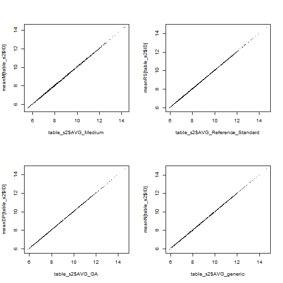

```r
# scatter plot correlation of the 4 columns in table_S2 vs. the reproduced numbers. String correlation.
par(mfrow=c(2, 2))
plot(table_s2$AVG_Medium, meanM[table_s2$ID], pch=".")
plot(table_s2$AVG_Reference_Standard, meanRS[table_s2$ID], pch=".")
plot(table_s2$AVG_GA, meanDP[table_s2$ID], pch=".")
plot(table_s2$AVG_generic, meanN[table_s2$ID], pch=".")
```

The numbers in Table S2 is almost reproduced.

**Table S3**

> The highly variable probes that were significant by F-test in either GA or generic (see methods section) and are depicted in Figure 1A. Figure text, Towfic et al.

> In order to identify probes with variability induced specifically by activation (as opposed to experimental noise), we sought to identify probes that were significantly more variable when activated with either GA or generic than medium. Using an F-test, we compared GA against Medium for each probe and compared generic against Medium. We then took the set of probes where either treatment comes up to be more variable than medium (union, passes in at least at least one). For those set of probes only, we compared the variability of GA across 34 samples representing 30 batches, to the variability of generic across 11 samples representing 5 batches, utilizing an F-test to measure significance of the differences between the probes. Methods, Towfic et al.

There is no description of what was used as a significance threshold in this table, but for the Identification of differentially expressed genes (Table S5), a FDR cut-off of 0-05 was applied.

```r
pvalsN = apply(datamatrices[["real_combat_covariates"]], 1, function(x) {
    var.test(x[sampleannotation$covariate == "N"], x[sampleannotation$covariate ==
        "M"], alternative = "greater")$p.value
})
pvalsDP = apply(datamatrices[["real_combat_covariates"]], 1, function(x) {
    var.test(x[sampleannotation$covariate == "DP"], x[sampleannotation$covariate ==
        "M"], alternative = "greater")$p.value
})
padjustedN = p.adjust(pvalsN, method = "BH")
padjustedDP = p.adjust(pvalsDP, method = "BH")
print(table(padjustedN < 0.05))
```

```
##
## FALSE
## 46237
```

```r
print(table(padjustedDP < 0.05))
```

```
##
## FALSE
## 46237
```

```r
# nothing significant acording to 5%FDR that was used in the Differentially
# expressed genes tests.
```

We are not able to reproduce this list. An alternative is to inspect the p-values for the probes in the list and see how they compare to the overall p-values.

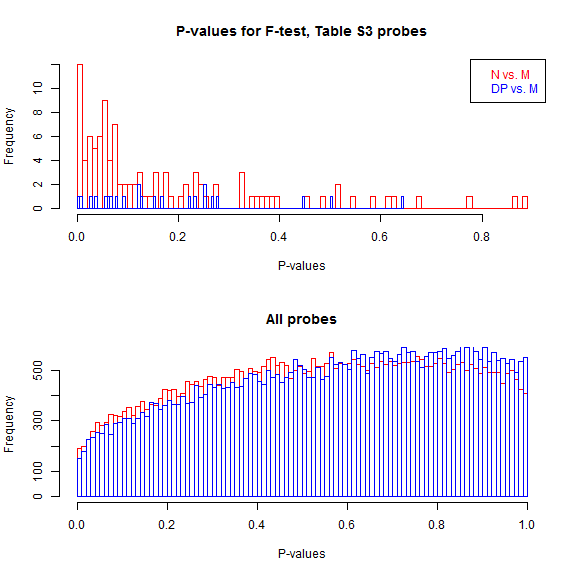

```r
par(mfrow=c(2, 1))
thiscolors = c("red", "blue")
hist( pvalsN[table_s3$Probe[table_s3$Type=="generic"]],
      breaks=100, border="red",
      main="P-values for F-test, Table S3 probes",
      xlab="P-values")
hist(pvalsDP[table_s3$Probe[table_s3$Type=="GA"]],
     breaks=100, border="blue", add=T)
legend("topright", legend=c("N vs. M", "DP vs. M"), text.col=c("red", "blue"))
hist( pvalsN,
      breaks=100, border="red",
      main="All probes", xlab="P-values")
hist(pvalsDP,
     breaks=100, border="blue", add=T)
```

The probes from Table S3 are at least enriched for low p-values. A more detailed explanation is needed for a better reproduction.

**Table S4**

> Ranked list of probes by ratio of the variance in generic-activated samples to the variance in GA-activated samples. Figure text, Towfic et al.

> Thus, we calculated for each probe the ratio of the variance in generic to the variance in GA

```r
# Table s4 f-test statistic is the same as ratio of variance?
fstatistics = apply(datamatrices[["real_combat_covariates"]], 1, function(x) {
    var.test(x[sampleannotation$covariate == "N"], x[sampleannotation$covariate ==
        "DP"], alternative = "greater")$statistic
})
fstatistics = fstatistics[order(fstatistics, decreasing = TRUE)]
table(names(fstatistics)[1:100] %in% table_s4$Probe)  # not a complete reproduction.
```

```
##
## FALSE  TRUE
##    69    31
```

Out of Table S4's **98** probes, **31** were reproduced.

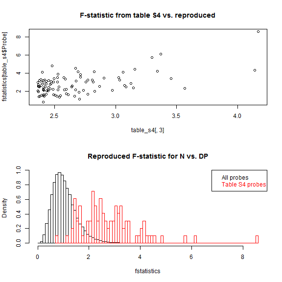

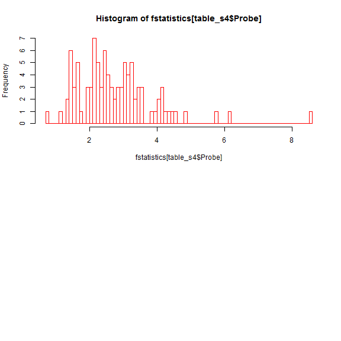

```r
par(mfrow=c(2, 1))
plot(table_s4[,3], fstatistics[table_s4$Probe], main="F-statistic from table S4 vs. reproduced")
thiscolors = c("black", "red")
hist(fstatistics, breaks=100, freq=F, border=thiscolors[1], main="Reproduced F-statistic for N vs. DP")
hist(fstatistics[table_s4$Probe], breaks=100, add=T, freq=F, border=thiscolors[2])
legend("topright", legend=c("All probes", "Table S4 probes"), text.col=thiscolors)

hist(fstatistics[table_s4$Probe], breaks=100, add=F, freq=T, border=thiscolors[2])
```

**Table S5**

> Comparison of expression in GA to expression in GA for each probe, including fold change, ANOVA, LIMMA with background subtraction, comparative marker selection by signal-to-noise ratio, comparative marker selection by t-test, and the Wilcoxon non-parametric method. Figure text, Towfic et al.

There must be a typo in the figure text, they ment “Comparison of expression in GA to expression in **generic** for each probe, …”.

> To find differentially expressed probes between generic and GA, we utilized various statistical tests at the probe level and merged the results across the different methods. Towfic et al.

How the fold change was calculated is not explained. A common way is to take the difference of geometric means that were calculated for Table S2 above.

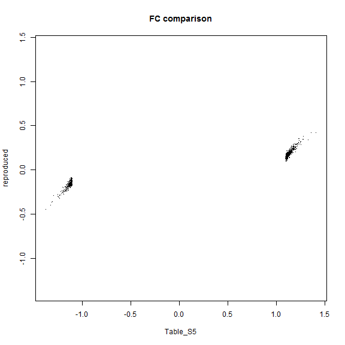

```r
foldchange_DP_N = meanDP - meanN

 # make the axis equal.
lim =c( min(   c(min(table_s5$Fold_Change), min(foldchange_DP_N[table_s5$Probe]))  ),
        max( c(max(table_s5$Fold_Change), max(foldchange_DP_N[table_s5$Probe])) ))

# plot
plot(table_s5$Fold_Change, foldchange_DP_N[table_s5$Probe],
     ylim=lim, xlim=lim, pch=".", xlab="Table_S5", ylab="reproduced",
     main="FC comparison")
rm(lim)
```

The plot reveals that the reproduced fold changes are much more compressed than the ones in Table S5. There seems to two linear relationship, one for neagtive FC's and another for positve FC's. They seems to have different intercepts but comparable slope.

The average expression for “GA” (DP) and “generic” (N) are also given in Table S2. The fold change calculated from those numbers compared to the ones given in Table S5 shows a similar pattern:

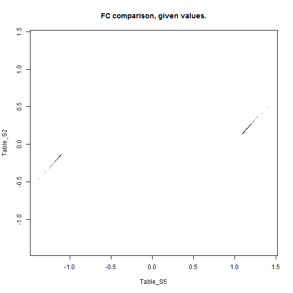

```r
# table S2 has the AVG for both DP and N listed
fc_table_s2 = table_s2$AVG_GA - table_s2$AVG_generic
names(fc_table_s2) = table_s2$ID
x = table_s5$Fold_Change
y = fc_table_s2[table_s5$Probe]
lim =c( min(   c(min(x, na.rm=T), min(y, na.rm=T))  ), max( c(max(x, na.rm=T), max(y, na.rm=T)) ))
plot(x, y , ylim=lim, xlim=lim, pch="." ,  xlab="Table_S5", ylab="Table_S2",
     main="FC comparison, given values.") #  almost perfect match with offset.
rm(x, y, lim, fc_table_s2)
```

We are not able to reporduce the foldchanges fully.

> First, we computed the statistical significance of differential expression between treatments using the Analysis of Variance (ANOVA) method for each probe [21]… Towfic et al.

```r
anova_p = apply(datamatrices[["real_combat_covariates"]], 1, function(x) {
    summary(aov(x[DP | N] ~ sampleannotation$covariate[DP | N]))[[1]][1, 5]
})
```

[output not shown]

> Next, we utilized Linear Models for Microarray (LIMMA) data analysis [23], [24] R package, part of the Bioconductor framework [25], to compare generic and GA samples, fitting a linear model that adjusts for fixed effect from medium (Effect = (GA-generic)  (generic-Medium)). The coefficients for the linear model were tested for significance using a modified t-test (taking into account standard deviation)… Towfic et al.

The formula “Effect = (GA-generic)  (generic-Medium)” seems strange. A more standard way would be GA-generic.

```r
group = factor(sampleannotation$covariate)
design = model.matrix(~0 + group)
fit = lmFit(datamatrices[["real_combat_covariates"]], design)
cont.matrix = makeContrasts(contrasts = "(groupDP-groupN) - (groupN-groupM)",
    levels = design)
fit2 = contrasts.fit(fit, cont.matrix)
limma_p_org = eBayes(fit2)$p.value

cont.matrix = makeContrasts(contrasts = "groupDP-groupN", levels = design)
fit2 = contrasts.fit(fit, cont.matrix)
limma_p_alt = eBayes(fit2)$p.value
```

> In parallel, we used Comparative Marker Selection as implemented in GenePattern [26] to directly compare probes between generic and GA. We applied two separate techniques within this framework; a traditional T-test and a Signal-to-Noise Ratio test (SNR).

The T-test is stright forward.

```r
DP = sampleannotation$covariate == "DP"
N = sampleannotation$covariate == "N"
ttest_p = apply(datamatrices[["real_combat_covariates"]], 1, function(x) {
    t.test(x[DP], x[N])$p.value
})
```

> …we used the Wilcoxon Rank Sum Test [27] as implemented in R …

```r
# wilcox.test gives a few hundred warnings for ties: Warning: cannot compute
# exact p-value with ties
wilcoxon_p = suppressWarnings(apply(datamatrices[["real_combat_covariates"]],
    1, function(x) {
        wilcox.test(x[sampleannotation$covariate == "DP"], x[sampleannotation$covariate ==
            "N"])$p.value
    }))
```

```r
par(mfrow=c(2, 2))
#plot(table_s5$Fold_Change, (meanDP - meanN)[table_s5$Probe] ,  ylim=c(-1.5,1.5), xlim=c(-1.5,1.5), pch=".", xlab="Table_S5", ylab="reproduced", main="FC comparison")
plot(log10(table_s5$t_test_p), log10(ttest_p[table_s5$Probe]), pch=".", main="t-test p")
plot(log10(table_s5$limma_p), log10(limma_p[table_s5$Probe]), pch=".", main="limma p")
```

[output not shown]

```r
plot(log10(table_s5$anova_p), log10(anova_p[table_s5$Probe]), pch=".", main="anova p")
```

[output not shown]

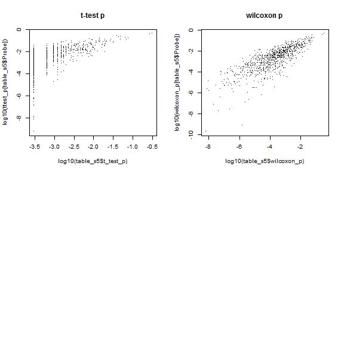

```r
plot(log10(table_s5$wilcoxon_p), log10(wilcoxon_p[table_s5$Probe]), pch=".", main="wilcoxon p")
```

# The p-values does not make a straight line, but they are low. But maybe all are low?

```r
par(mfrow=c(2, 2))
thiscolors=c("black", "red")
hist(ttest_p, border=thiscolors[1], main="Reproduced t-test p-value distribution.", breaks=100)
hist(ttest_p[table_s5$Probe], border=thiscolors[2], add=T, breaks=100)
legend("topright", legend=c("all probes", "S5 probes"), text.col=thiscolors)
hist(limma_p, border=thiscolors[1], main="Reproduced limma p-value distribution.", breaks=100)
```

[output not shown]

```r
hist(limma_p[table_s5$Probe], border=thiscolors[2], add=T, breaks=100)
```

[output not shown]

```r
legend("topright", legend=c("all probes", "S5 probes"), text.col=thiscolors)
hist(anova_p, border=thiscolors[1], main="Reproduced anova p-value distribution.", breaks=100)
```

[output not shown]

```r
hist(anova_p[table_s5$Probe], border=thiscolors[2], add=T, breaks=100)
```

[output not shown]

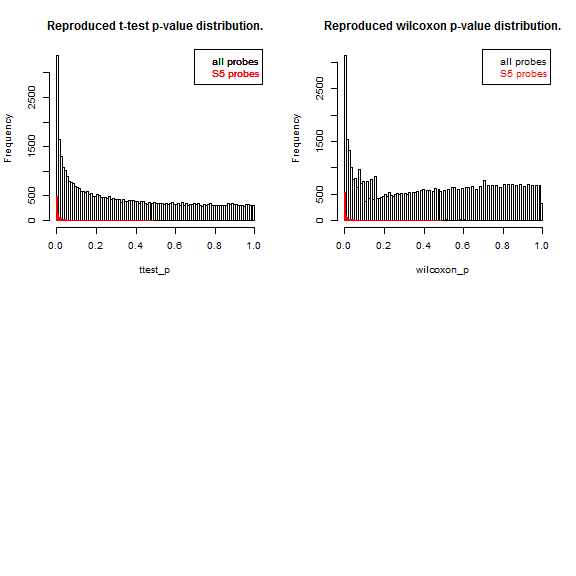

```r
legend("topright", legend=c("all probes", "S5 probes"), text.col=thiscolors)
hist(wilcoxon_p, border=thiscolors[1], main="Reproduced wilcoxon p-value distribution.", breaks=100)
hist(wilcoxon_p[table_s5$Probe], border=thiscolors[2], add=T, breaks=100)
legend("topright", legend=c("all probes", "S5 probes"), text.col=thiscolors)
```